# Githubfor pedagogical purposes

May 2, 2018

## Outline

1. What and why of version control
2. Habit formation
3. Hands-on: use Git and Github to edit "homework" and "submit it"
4. A tour through how we use Github as a course delivery system
5. Teaching Git and Github - pedagogical best practices
6. When is it appropriate to use Git and Github as a course delivery system

## What and why of version control

## What is version control?

[figure not shown]

source: [Software Carpentry Git lesson](http://swcarpentry.github.io/git-novice/)

## What version control tooling?

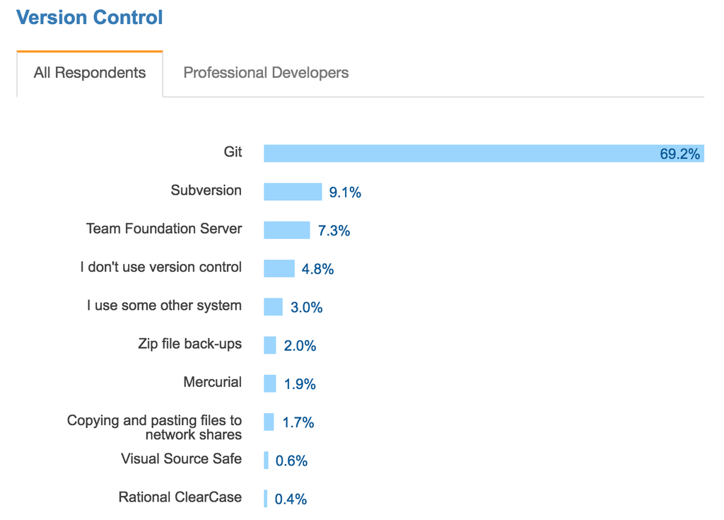

source: [Stack Overflow Developer Survey Results 2017](https://insights.stackoverflow.com/survey/2017)

## What version control tooling?

*"In 2017, the GitHub community reached 24 million developers."*

source: [Github](https://github.com/)

## What version control tooling?

[figure not shown]

## Why of version control?

[figure not shown]

## Habit formation

## habits

*Definition*:

*Behaviours arising from repetitive reinforcement learning that persist after removal or devaluation of reinforcements ([Smith & Graybiel, 2016](https://www.ncbi.nlm.nih.gov/pmc/articles/PMC4826769/)).*

## Why do we care about creating version control habits?

- Version control is an expected hourly/daily task of a professional Data Scientist (and many other computational jobs)
- Takes significant cognitive effort for novices to use version control tools
- Behaviours that become habits require minimal cognitive effort, freeing up cognitive resources for other tasks

## How do we create version control habits in the UBC Master of Data Science program?

We provide:

1. scaffolding and support for learning
2. reinforcement for desired behaviour
3. opportunities to practice (repetition)

## Learning scaffolding and support

- Teach our students to use Git and Github on day 1 of the program
- Use hands-on, live-coding, workshop-like approach
- provide Git and Github written tutorials, cheatsheets, etc

## Reinforcement!

- Github is the required tool for submitting work
- performance of using version control is evaluated and assessed (counts towards grades)

## Repetition!

Over 10 months, students use version control > 300 times to:

- access and submit labs
- access and submit quizzes
- work iteratively on individual projects
- work collaboratively on group projects
- give and receive peer feedback
- receive feedback from TAs and Instructors

## Hands-on: use Git and Github to edit "homework" and "submit it"

All instructions are linked to from the Github repository for this course: https://github.com/ttimbers/github_course_delivery_system

## Set-up

*assuming you have a UBC cwl…*

- Sign up for an account with [Github.com](https://github.com/) (if you don't already have one)
- login to [ubc.syzygy.ca](https://ubc.syzygy.ca/) with your cwl
- Click on:
  1. "Start Server"
  2. "New" > "Terminal"
  3. enter the following (changing the values in the quotes to ones appropriate for your [Github.com](https://github.com/) account)

     ```
     git config --global user.name "ttimbers""
     git config --global user.email "tiffany.timbers@gmail.com"
     ```

  *note - the quotes are still necessary*

## Activity overview

Now that we're set up to use Git, let's walk through a workflow very similar to what the students would do (and learn a little Git along the way!)

1. Get your own copy of the example homework folder (Github repository)
2. "clone"" that copy to a place you can edit the files (e.g.,[ubc.syzygy.ca](https://ubc.syzygy.ca/) or your own computer if you have already have Git installed there)
3. Edit and save the changes to the files
4. Use Git to log the changes ("add" and "commit")
5. Send the logged Git changes to Github ("push") to submit the work

## 1. Get your own copy

Go to the URL below and click on the "Fork" button (top right-hand corner)

https://github.com/UBC-MDS/eg_hwk

## 2. "clone"" that copy to a place you can edit the files

- Click on the "Clone or download" (green button) of the new website you were directed to. Copy the URL that pops up.
- Go back to the "Terminal" on [ubc.syzygy.ca](https://ubc.syzygy.ca/) and type the following (replace URL with the URL you just copied):

  ```
  git clone URL
  ```

- using "Terminal" navigate into that directory by typing:

  ```
  cd eg_hwk
  ```

## 3. Edit and save the changes to the files

- Click on the "Home" [ubc.syzygy.ca](https://ubc.syzygy.ca/) tab in your browser and use the file navigator to find `homework.md` in the `eg_hwk` directory/folder
- Follow the instructions to answer the homework questions
- Save the changes (File -> Save)

## 4. Use Git to log the changes

- Go back to the "Terminal" on [ubc.syzygy.ca](https://ubc.syzygy.ca/)
- Ask Git what files were changed by typing: `git status`
- log those changes to git by typing the following two lines into terminal:

  ```
  git add homework.md

  git commit -m "first attempt at homework questions"
  ```

*note the message in the quotes is required but can (and should) be customized each time you log changes*

## 5. Send the logged Git changes to Github ("push") to submit the work

- In the "Terminal" on [ubc.syzygy.ca](https://ubc.syzygy.ca/) type (*note - you will be asked to enter your Github username and password here*):

  ```
  git push
  ```

- Go back to your copy of the homework on [Github.com](https://github.com/) and check to see that you were successful in submitting this homework.

## Reflect on workflow

- its not simple or easy!
- but its a powerful tool and an essential skill for those who use computation!

## A tour through how we use Github as a course delivery system

## rhomboid

A set of tools for delivering a course on GitHub:

- collection of Python scripts
- most act to get or send data to the Github API
- instructors interact with rhomboid via the command line/terminal
- students interact with Git and Github
- Github repository: https://github.com/mgelbart/rhomboid

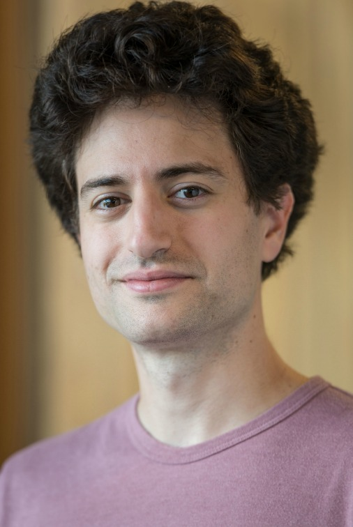

Michael Gelbart, Ph.D.

## rhomboid in action

https://github.ubc.ca/ubc-mds-2017

*note - most of you will not have access to the link above*

## Teaching Git and Github - pedagogical best practices

## Teaching Git and Github - pedagogical best practices

(alternate slide title: Lessons learned…)

- go slowly and have the students practice (many repetitions!)
- use a motivating example (e.g., homework, updating a blog/website)
- start by introducing version control using the Github website first
- use the command line to teach students to use git (as opposed to the GUI's)
- teach only what is needed (`git push` instead of `git push origin master`)
- teach best practices of version control along with the tools
- introduce more advanced Git and Github features over time

## When is it appropriate to use Git and Github as a course delivery system

- Students have some computing background, and/or…
- Students have motivation/need to use version control beyond your single course

## What we just covered

1. What and why of version control
2. Habit formation
3. Hands-on: use Git and Github to edit "homework" and "submit it"
4. A tour through how we use Github as a course delivery system
5. Teaching Git and Github - pedagogical best practices
6. When is it appropriate to use Git and Github as a course delivery system